# NYC Council Data Science Test - CODE and APPENDIX

### **4. What model would you build to predict crime to better allocate NYPD resources? What challenges do you foresee? What variables would be included? How would you evaluate the model? Discuss in no more than 150 words.**

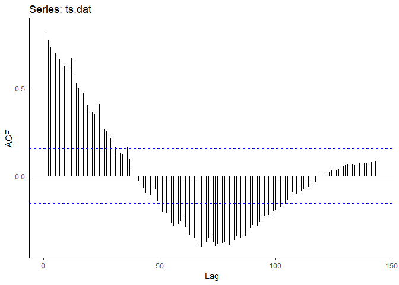

```r
# Stationary
ggAcf(x = ts.dat, lag.max = 12*12)
```

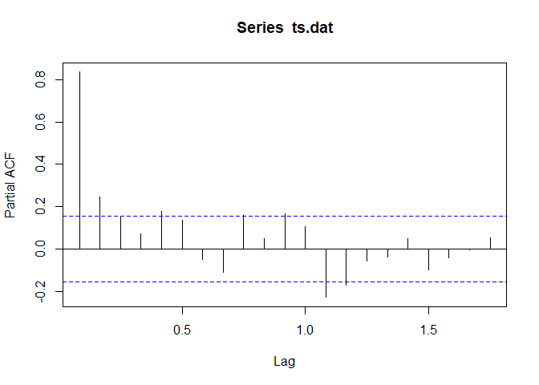

```r
pacf(ts.dat)
```

```r
# Random Walk test:
Box.test(ts.dat, type = "Ljung-Box", lag = 12*12) # NOT WHITE NOISE
```

```
    Box-Ljung test

data:  ts.dat
X-squared = 3318.2, df = 144, p-value < 2.2e-16
```

```r
# Stationary test restrict one!
adf.test(ts.dat, alternative="stationary", k = 0) # p = 0.01. That is, it is stationary.
```

```
    Augmented Dickey-Fuller Test

data:  ts.dat
Dickey-Fuller = -4.337, Lag order = 0, p-value = 0.01
alternative hypothesis: stationary
```

```r
# Stationary around trend test
kpss.test(ts.dat, null = 'Trend', lshort = T) # p-val = 0.01, The null hypothesis of stationarity around a trend is rejected.
```

```
    KPSS Test for Trend Stationarity

data:  ts.dat
KPSS Trend = 0.68065, Truncation lag parameter = 4, p-value = 0.01
```

```r
# White noise around trend test
kpss.test(ts.dat, null = 'Level', lshort = T) # p-val = 0.01:  The null hypothesis of stationarity around a level is rejected.
```

```
    KPSS Test for Level Stationarity

data:  ts.dat
KPSS Level = 1.4616, Truncation lag parameter = 4, p-value = 0.01
```

As a stationary check, I ran the Dickey–Fuller Test (adf.test), Kwiatkowski-Phillips-Schmidt-Shin (kpss.test), and the Ljung-Box test(Box.test). According to the p-values of `Box.test` and `kpss.test`, it is a random walk; however, `adf.test` says otherwise: the data is stationary. The result of `adf.test` contradicts that of `kpss.test`. It may be caused because I do not have enough data or neither test is powerful enough to reject the null hypothesis. **Here, the rate is not stabilized, which could be done with Box-Cox Transformation as followed: `BoxCox(ts.dat,lambda = BoxCox.lambda(ts.dat))`. Also, the trend and seasonality are not removed yet**

How about Additive or Multiplicative?

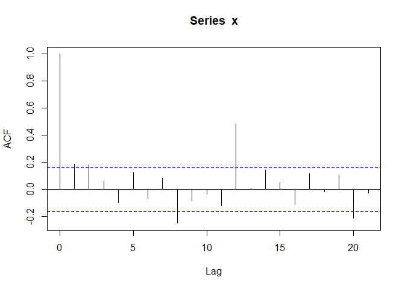

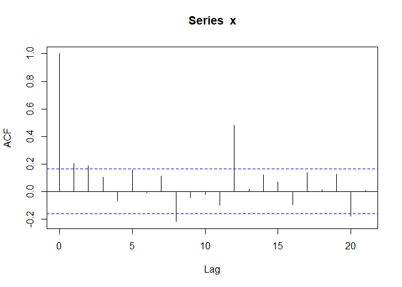

```
          ts_type
1: Multiplicative
```

```r
arrest.dat[, trend:= rollmean(x = Rate, k = 12, fill=NA, align = "right")]

arrest.dat[,`:=`(detrended_add = Rate - trend,  detrended_mult = Rate / trend )]

arrest.dat[, yr_mon:= paste0(yr_mon,"-01")]
arrest.dat$yr_mon = as.Date(arrest.dat$yr_mon)

arrest.dat[,`:=`
           (seasonal_add = mean(detrended_add, na.rm = TRUE),
            seasonal_mult = mean(detrended_mult, na.rm = TRUE)), by=.(quarter(yr_mon))]

arrest.dat[,`:=`
           (residual_add = detrended_add - seasonal_add,
            residual_mult = detrended_mult / seasonal_mult )]

arrest.dat[,.(ts_type = compare_ssacf(residual_add, residual_mult))] # Multiplicative
```

What would be the best model?

```r
# split the data into train and test:
train = window(ts.dat, end = c(2014, 12))
test = window(ts.dat, start = c(2015, 01))
length(train)
```

```
[1] 108
```

```r
length(test)
```

```
[1] 48
```

```r
## Avg Method:
average_model = meanf(train,h = 48)
accuracy(average_model,x = ts.dat)
```

```
                        ME      RMSE       MAE         MPE      MAPE     MASE
Training set  6.894562e-16  5.851318  4.673077   -8.404388  24.20025 1.025679
Test set     -1.097932e+01 11.780223 10.979322 -119.120799 119.12080 2.409818
                  ACF1 Theil's U
Training set 0.6461398        NA
Test set     0.8193088  5.405354
```

```r
## Naive Method:
naive_model = naive(train,h=48)
accuracy(naive_model,x = ts.dat)
```

```
                      ME     RMSE      MAE       MPE     MAPE      MASE
Training set -0.05490004 4.621628 3.583446 -3.248599 17.51529 0.7865195
Test set      4.49220139 6.197420 4.763585 28.584154 33.66600 1.0455446
                   ACF1 Theil's U
Training set -0.3576170        NA
Test set      0.8193088  1.620428
```

```r
## Seasonal Naive Method:
seasonal_naive_model = snaive(train,h=48)
accuracy(seasonal_naive_model,x = ts.dat)
```

```
                     ME      RMSE      MAE         MPE     MAPE     MASE
Training set  0.7644501  5.454814 4.556080   0.8382564 20.37295 1.000000
Test set     -8.6315622 10.160929 8.790532 -89.9218680 91.29253 1.929407
                  ACF1 Theil's U
Training set 0.5145345        NA
Test set     0.4086452  4.351039
```

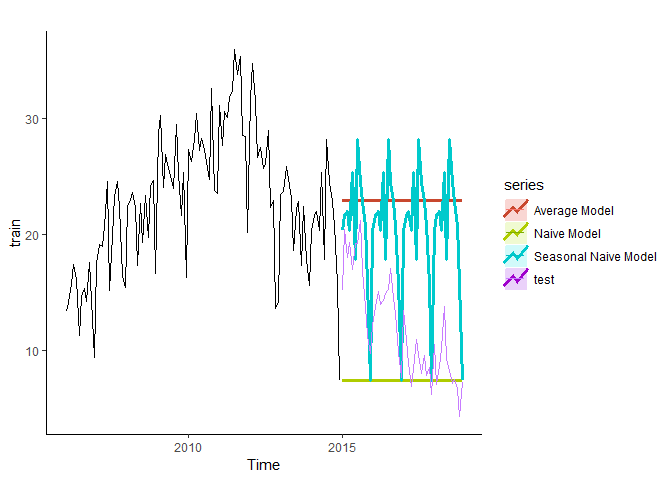

```r
## Plots 1:
autoplot(train)+
  autolayer(average_model,PI = F,size=1.1,series = 'Average Model')+
  autolayer(naive_model,PI=F,size=1.1, series='Naive Model')+
  autolayer(seasonal_naive_model,PI=F,size=1.1,series='Seasonal Naive Model')+
  autolayer(test)
```

```r
## Drift Method:
drift_model = rwf(train,h=48,drift = T)
accuracy(drift_model,x = ts.dat)
```

```
                        ME     RMSE      MAE      MPE     MAPE      MASE
Training set -1.161957e-15 4.621301 3.583959 -2.99072 17.49340 0.7866321
Test set      5.837252e+00 6.891858 5.859245 43.60097 44.10395 1.2860276
                   ACF1 Theil's U
Training set -0.3576170        NA
Test set      0.7684354  1.977951
```

```r
## Holt's Method with Damping:
holt_damped_model = holt(train,h=48,damped = T)
accuracy(holt_damped_model,x = ts.dat)
```

```
                     ME     RMSE      MAE        MPE     MAPE      MASE
Training set -0.2728191 4.083304 3.233465  -5.245902 16.64397 0.7097034
Test set     -4.3997699 6.150654 5.299161 -56.399255 61.00296 1.1630965
                  ACF1 Theil's U
Training set 0.1109748        NA
Test set     0.8211833  2.966668
```

```r
## Holt-Winter's Seasonal Method with Multiplicative:
hw_mult = hw(train,h=48,seasonal = 'multiplicative', damped=T)
accuracy(hw_mult,x = ts.dat)
```

```
                    ME     RMSE      MAE       MPE     MAPE      MASE
Training set -0.285085 2.789163 2.129451  -3.15087 10.31493 0.4673866
Test set     -5.395353 6.634401 5.715367 -62.66821 64.26902 1.2544483
                     ACF1 Theil's U
Training set -0.008352425        NA
Test set      0.805870284  3.041418
```

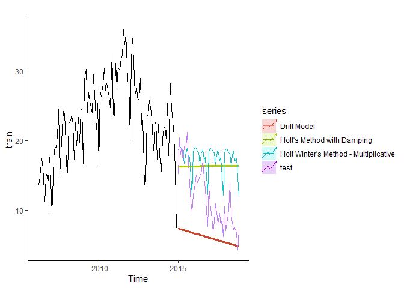

```r
## Plots 2:
autoplot(train)+
  autolayer(drift_model,PI=F,size=1.1,series='Drift Model')+
  autolayer(holt_damped_model,series="Holt's Method with Damping",PI=F,size=1.1)+
  autolayer(hw_mult,series="Holt Winter's Method - Multiplicative",PI=F)+
  autolayer(test)
```

```r
model.types = c("MAM","ANA","MNM","MAM","MMM")
ets.models = list()
ets.forecast = list()
for(i in seq(model.types)){
  ets.models[[i]] = ets(train, model =  model.types[i])
  summary(ets.models[[i]])

  ets.forecast[[i]] = forecast(ets.models[[i]],h=48)

  accuracy(ets.forecast[[i]],x = ts.dat)
}
```

```
ETS(M,Ad,M)

Call:
 ets(y = train, model = model.types[i])

  Smoothing parameters:
    alpha = 0.3449
    beta  = 0.0042
    gamma = 2e-04
    phi   = 0.9756

  Initial states:
    l = 12.2635
    b = 0.4778
    s = 0.6763 0.8785 1.0353 0.9867 1.0937 1.0529
           0.9501 1.0701 1.0689 1.0684 1.07 1.049

  sigma:  0.1383

     AIC     AICc      BIC
768.7839 776.4693 817.0623

Training set error measures:
                     ME     RMSE     MAE       MPE     MAPE      MASE
Training set -0.2924841 2.801256 2.15055 -2.895692 10.23482 0.4720175
                    ACF1
Training set -0.02553174
ETS(A,N,A)

Call:
 ets(y = train, model = model.types[i])

  Smoothing parameters:
    alpha = 0.4314
    gamma = 2e-04

  Initial states:
    l = 17.0538
    s = -7.7423 -3.1752 0.5966 0.0543 2.3921 0.9692
           -0.6522 1.5254 1.9558 1.7447 1.7548 0.5768
```

[output cut: 74 more lines]

```
    l = 12.6057
    b = 1.0381
    s = 0.6808 0.8731 1.0429 0.9878 1.085 1.0414
           0.9514 1.0666 1.0767 1.0723 1.0802 1.0419

  sigma:  0.1387

     AIC     AICc      BIC
769.8936 777.5790 818.1720

Training set error measures:
                     ME     RMSE      MAE       MPE     MAPE      MASE
Training set -0.3322622 2.819486 2.156706 -3.129483 10.29787 0.4733687
                     ACF1
Training set -0.007011273
```

```r
## Exponential Smoothing Methods(ETS)-xxx and auto:
ets_mmm = ets(train, model = 'MMM')
summary(ets_mmm)
```

```
ETS(M,Md,M)

Call:
 ets(y = train, model = "MMM")

  Smoothing parameters:
    alpha = 0.3269
    beta  = 0.008
    gamma = 1e-04
    phi   = 0.964

  Initial states:
    l = 12.6057
    b = 1.0381
    s = 0.6808 0.8731 1.0429 0.9878 1.085 1.0414
           0.9514 1.0666 1.0767 1.0723 1.0802 1.0419

  sigma:  0.1387

     AIC     AICc      BIC
769.8936 777.5790 818.1720

Training set error measures:
                     ME     RMSE      MAE       MPE     MAPE      MASE
Training set -0.3322622 2.819486 2.156706 -3.129483 10.29787 0.4733687
                     ACF1
Training set -0.007011273
```

```r
ets_auto = ets(train)
summary(ets_auto) # ANA
```

```
ETS(A,N,A)

Call:
 ets(y = train)

  Smoothing parameters:
    alpha = 0.4314
    gamma = 2e-04

  Initial states:
    l = 17.0538
    s = -7.7423 -3.1752 0.5966 0.0543 2.3921 0.9692
           -0.6522 1.5254 1.9558 1.7447 1.7548 0.5768

  sigma:  3.0218

     AIC     AICc      BIC
759.5404 764.7578 799.7724

Training set error measures:
                     ME     RMSE      MAE       MPE     MAPE      MASE
Training set 0.02490398 2.819152 2.203749 -1.345635 10.49735 0.4836941
                    ACF1
Training set -0.07352409
```

```r
ets_mmm_forecast = forecast(ets_mmm,h=48)
ets_auto_forecast = forecast(ets_auto,h=48)

accuracy(ets_mmm_forecast,x = ts.dat)
```

```
                     ME     RMSE      MAE        MPE     MAPE      MASE
Training set -0.3322622 2.819486 2.156706  -3.129483 10.29787 0.4733687
Test set     -4.0855237 5.386802 4.547006 -49.176390 51.50345 0.9980084
                     ACF1 Theil's U
Training set -0.007011273        NA
Test set      0.755834985  2.459622
```

```r
accuracy(ets_auto_forecast,x = ts.dat)
```

```
                      ME     RMSE      MAE        MPE     MAPE      MASE
Training set  0.02490398 2.819152 2.203749  -1.345635 10.49735 0.4836941
Test set     -6.24149318 7.470189 6.357862 -69.911045 70.49846 1.3954676
                    ACF1 Theil's U
Training set -0.07352409        NA
Test set      0.74438971  3.357134
```

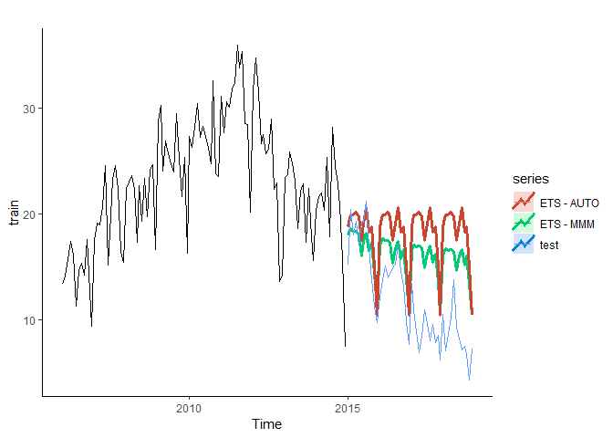

```r
## Plots 3:
autoplot(train)+
  autolayer(ets_mmm_forecast,size = 1.1, series="ETS - MMM",PI=F)+
  autolayer(ets_auto_forecast,size = 1.1, series="ETS - AUTO",PI=F)+
  autolayer(test)
```

```r
## ARIMA:

### Stablizing:
train2 = BoxCox(train,lambda = BoxCox.lambda(train))
optimal.lamda = BoxCox.lambda(train)
kpss.test(train2) # Still non-staionary
```

```
    KPSS Test for Level Stationarity

data:  train2
KPSS Level = 0.67446, Truncation lag parameter = 4, p-value = 0.01587
```

```r
### Removing Seasonality:
train2_no_seasonality = diff(x = train2,lag = 12)
kpss.test(train2_no_seasonality) # Still non-staionary
```

```
    KPSS Test for Level Stationarity

data:  train2_no_seasonality
KPSS Level = 1.2594, Truncation lag parameter = 3, p-value = 0.01
```

```r
ndiffs(train2_no_seasonality) #1
```

```
[1] 1
```

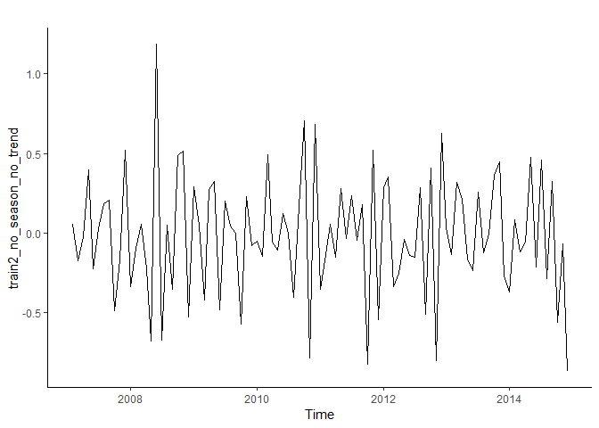

```r
### Removing Trend:
train2_no_season_no_trend = diff(train2_no_seasonality,1)
autoplot(train2_no_season_no_trend)
```

```r
kpss.test(train2_no_season_no_trend) # Now stationary!!
```

```
    KPSS Test for Level Stationarity

data:  train2_no_season_no_trend
KPSS Level = 0.061781, Truncation lag parameter = 3, p-value = 0.1
```

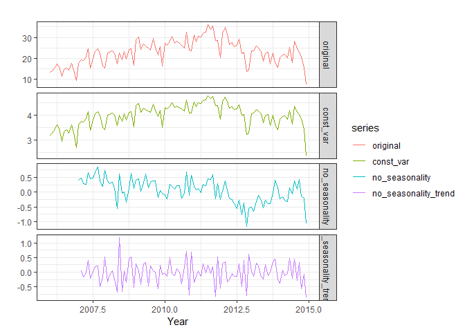

```r
plot =
    cbind(
      original = train,
      const_var = train2,
      no_seasonality = train2_no_seasonality,
      no_seasonality_trend = train2_no_season_no_trend)

autoplot(plot,facets=T,colour = T)+ylab('')+xlab('Year')+theme_bw()
```

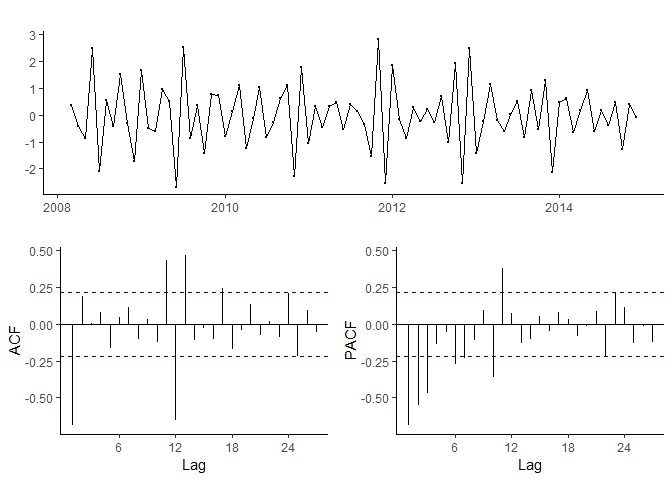

```r
### Examine ACF and PACF to decide on AR (ARIMA(p,d,0) and/or MA terms (ARIMA(0,d,q))
train2_no_season_no_trend %>%
  diff(lag=12)%>%
  diff(lag=1)%>%
  ggtsdisplay()
```

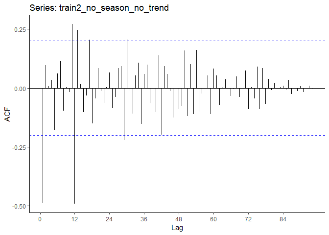

```r
ggAcf(train2_no_season_no_trend, lag.max = 12*12)# First lag is NEGATIVE: MA model. That is, ARIMA(0, d, q)
```

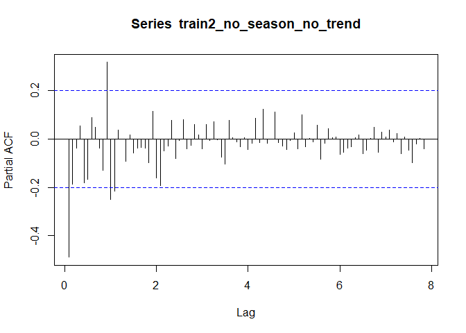

```r
pacf(train2_no_season_no_trend, lag.max = 12*12)# bit gradually decrease than acf
```

```r
### Try chose a model by selecing the min AICc:
arima.model1 = Arima(y = train,order = c(0,1,2),seasonal = c(0,1,1),lambda = BoxCox.lambda(train))
arima.model1
```

```
Series: train
ARIMA(0,1,2)(0,1,1)[12]
Box Cox transformation: lambda= 0.1554194

Coefficients:
          ma1     ma2     sma1
      -0.6215  0.0621  -0.8041
s.e.   0.1136  0.1014   0.1629

sigma^2 estimated as 0.06162:  log likelihood=-7.23
AIC=22.46   AICc=22.9   BIC=32.67
```

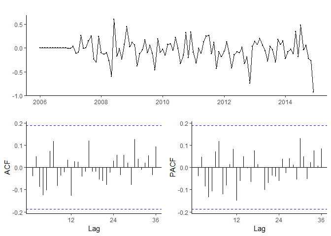

```r
ggtsdisplay(residuals(arima.model1))
```

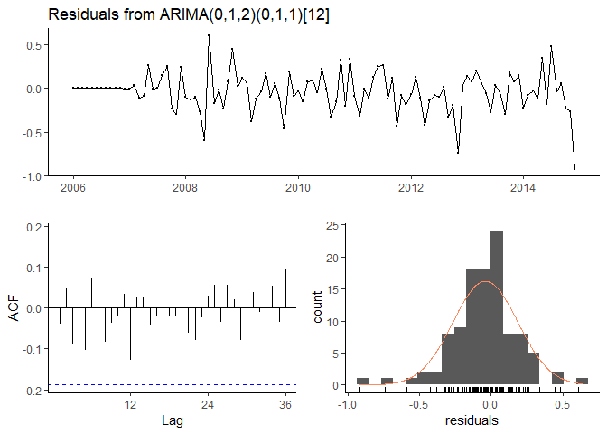

```
    Ljung-Box test

data:  Residuals from ARIMA(0,1,2)(0,1,1)[12]
Q* = 14.06, df = 19, p-value = 0.7802

Model df: 3.   Total lags used: 22
```

```r
checkresiduals(arima.model1)## NOT FIT YET!
```

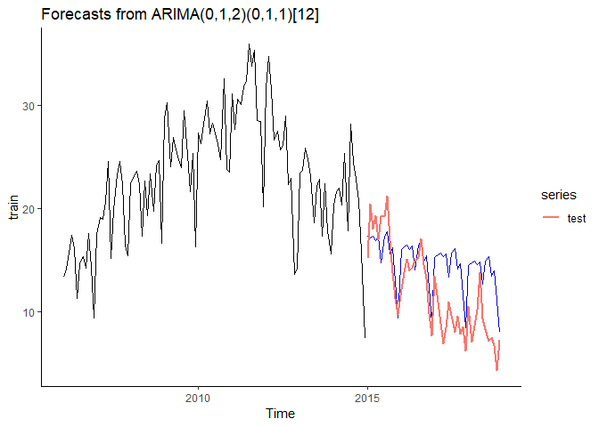

```r
autoplot(forecast(arima.model1,h = 48),PI=F)+
  autolayer(test,size=1)
```

```r
### Alternative:
arima.model2 = Arima(y = train, order = c(0,1,1),seasonal = c(0,1,1),lambda = BoxCox.lambda(train))
arima.model2
```

```
Series: train
ARIMA(0,1,1)(0,1,1)[12]
Box Cox transformation: lambda= 0.1554194

Coefficients:
          ma1     sma1
      -0.5976  -0.7987
s.e.   0.0961   0.1596

sigma^2 estimated as 0.06135:  log likelihood=-7.42
AIC=20.83   AICc=21.1   BIC=28.49
```